# FP2–V3. Određivanje gustoće tekućina

## Matija Pajas

### Zadatak 1

Izmjerite gustoću vode u temperaturnom intervalu od $0 \ ^{\mathrm{o}}\mathrm{C}$ do $48 \ ^{\mathrm{o}}\mathrm{C}$. Razmak temperatura na kojima se mjeri ne treba biti veći od $2-3 \ ^{\mathrm{o}}\mathrm{C}$, a oko $20 \ ^{\mathrm{o}}\mathrm{C}$ i $40 \ ^{\mathrm{o}}\mathrm{C}$ i gušće.

Prije nego što se moglo započeti mjerenje, bilo je potrebno baždariti Mohr-Westphalovu vagu. Vaga i utezi moraju biti suhi, a utezi jahači moraju biti na početnom položaju u nuli te se tada vrte vijci dok šiljci nisu jedan nasuprot drugome. Tako je osigurano da vaga počinje od nule. Destilirana voda hladi se ledom uz miješanje što bliže temperaturi ledišta nakon čega se uroni uteg vage u čašu sa vodom. Pomicanjem utega jahača potrebno je ponovo uspostaviti ravnotežu vage, a jahači će prikazivati gustoću. Mjerenja se ponavljaju kako se voda grije prema sobnoj temperaturi, a kako bi se mjerile više temperature koristi se vodena kupka i grijač. U mjerenje treba uzeti u obzir sustavnu pogrešku od $-0,001 \ \mathrm{g \cdot c m^{-3}}$ zbog uzgona zraka.

Mjerenja se nalaze u idućoj tablici popraćena pripadnim grafom dobivenim iz podataka:

[output not shown]

Najveća gustoća izmjerena je na $4 \ ^{\mathrm{o}}\mathrm{C}$ te na grafu označena crvenom točkom.

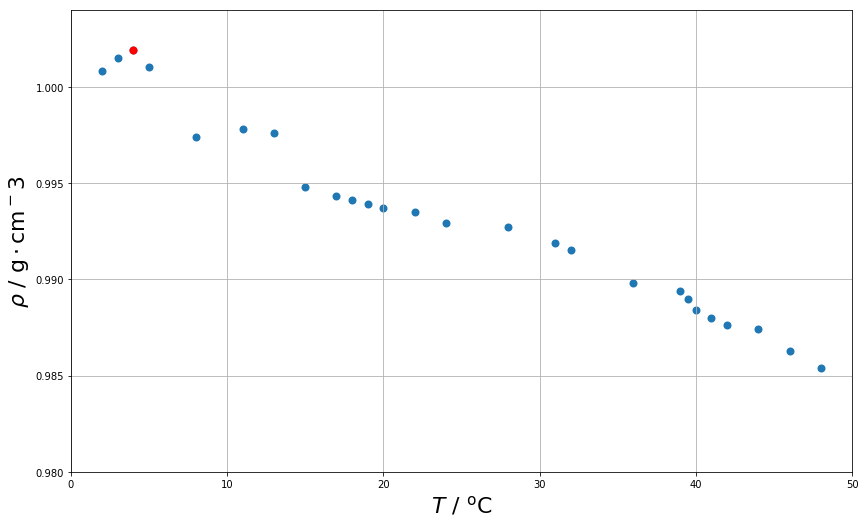

### Zadatak 2:

Metodom najmanjih kvadrata odredite koeficijent ekspanzije destilirane vode pri temperaturama $20 \ ^{\mathrm{o}}\mathrm{C}$ i $40 \ ^{\mathrm{o}}\mathrm{C}$. Da ne bismo morali uvoditi dodatne pretpostavke o vrijednosti $\rho$ koja stoji pred derivacijom iz jednadžbe (1), primijetite da se isti izraz može zapisati kao:

$$\alpha=-\frac{\partial \ln \rho}{\partial T}$$

Na kako transformirane toćke ćete stoga primijeniti metodu najmanjih kvadrata (kao i uvijek, u općenitom obliku y = ax + b) da biste odredili $\alpha$?

Počevši od jednadžbe (1) sa početka pripreme može se malo urediti izraz:

$$ \begin{align} \alpha &=-\frac{1}{\rho}\frac{\partial \rho}{\partial T} \\ -\alpha \mathrm{d} T &= \frac{\mathrm{d} \rho}{\rho} \end{align} $$

Te je sada jasno da integriranjem izraza možemo dobiti implicitnu ovisnost $\rho$ o T:

$$\ln \left ( \rho \right ) = -\alpha T + const.$$

Ovu izraz prepoznajemo kao jednadžbu pravca $y=ax + b$ i odredimo pripadne veličine:

$$ \begin{align} y &= \ln \left ( \rho \right ) \\ x &= T \\ a &= -\alpha \\ b &= const \end{align} $$

Nepouzdanost od $\alpha$ jednaka je nepouzdanosti parametra a: $$ M_{\alpha}=\sqrt{\left ( \frac{\partial \alpha}{\partial a} M_{a}\right )^2}= \sqrt{\left ( - M_{a}\right )^2}=M_a $$

Te sada možemo provesti metodu najmanjih kvadrata nad podacima oko $20 \ ^{\mathrm{o}}\mathrm{C}$ i $40 \ ^{\mathrm{o}}\mathrm{C}$.

Tablica mjerenja za točke oko $20 \ ^{\mathrm{o}}\mathrm{C}$:

|  | $T$ / $^{\mathrm{o}}\mathrm{C}$ | $\rho$ / $\mathrm{\frac{g}{{cm}^3}}$ | $\ln(\rho)$ |
| --- | --- | --- | --- |
| 1 | 17 | 0,9943 | -0,005716 |
| 2 | 18 | 0,9941 | -0,005917 |
| 3 | 19 | 0,9939 | -0,006119 |
| 4 | 20 | 0,9937 | -0,006320 |
| 5 | 22 | 0,9935 | -0,006521 |

Pripadni graf:

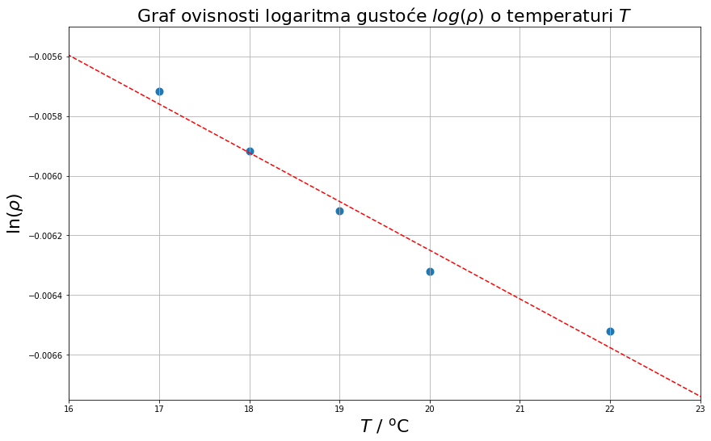

Koeficijenti dobiveni metodom najmanjih kvadrata:

$a = -0,00016316016521025905 \pm 0,000015690353240153495$

$b = -0,0029860463286447863 \pm 0,00030246182867556113$

### Rezultat:

$$\alpha_{20^\mathrm{0}\mathrm{C}} = (0,00016 \pm 0,00002) \ \frac{1}{^{\mathrm{o}}\mathrm{C}}$$

Tablica mjerenja za točke oko $40 \ ^{\mathrm{o}}\mathrm{C}$:

|  | $T$ / $^{\mathrm{o}}\mathrm{C}$ | $\rho$ / $\mathrm{\frac{g}{{cm}^3}}$ | $\ln(\rho)$ |
| --- | --- | --- | --- |
| 1 | 39,0 | 0,9894 | -0,010657 |
| 2 | 39,5 | 0,9890 | -0,011061 |
| 3 | 40,0 | 0,9884 | -0,011668 |
| 4 | 41,0 | 0,9880 | -0,012073 |
| 5 | 42,0 | 0,9876 | -0,012478 |

Pripadni graf:

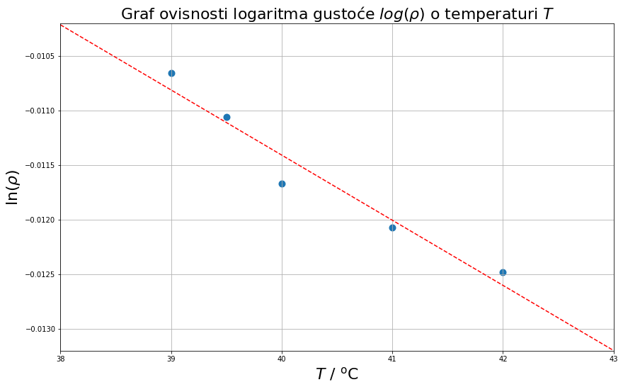

Koeficijenti dobiveni metodom najmanjih kvadrata:

$a = -0,000596541355468107 \pm 0,00008085829259866821$

$b = 0,012453529593161159 \pm 0,003259752695224384$

### Rezultat:

$$\alpha_{40^\mathrm{0}\mathrm{C}} = (0,0006 \pm 0,00008) \ \frac{1}{^{\mathrm{o}}\mathrm{C}}$$

## Zaključak:

U prvome zadatku najveća gustoća vode izmjerena je na $4 \ ^{\mathrm{o}}\mathrm{C}$ što se definitivno očekuje, ali mjerenja znatno odstupaju od stvarnih vrijednosti gustoće vode. Za usporedbu, kod $4 \ ^{\mathrm{o}}\mathrm{C}$ očekuje se oko $0,999972 \ \mathrm{\frac{g}{{cm}^3}}$ dok je izmjereno $1,0019 \ \mathrm{\frac{g}{{cm}^3}}$,

dok se za $20 \ ^{\mathrm{o}}\mathrm{C}$ očekuje $0,9982071 \ \mathrm{\frac{g}{{cm}^3}}$, a izmjereno je $0,9937 \ \mathrm{\frac{g}{{cm}^3}}$.

Razlog tomu je što vaga nije dovoljno dobro baždarena na početku te se u mjerenje potkrala pogreška uz greške uzrokovane diranjem utega toplomjerom te gibanja vode i preostalih komadića leda.

Uspoređujući izmjerene vrijednosti sa tabličnim podacima jasno se vidi da stvarna vrijednost nije u intervalu nepouzdanosti.

Izmjereno: $$\alpha_{20^\mathrm{0}\mathrm{C}} = (0,00016 \pm 0,00002) \ \frac{1}{^{\mathrm{o}}\mathrm{C}}$$

$$\alpha_{40^\mathrm{0}\mathrm{C}} = (0,0006 \pm 0,00008) \ \frac{1}{^{\mathrm{o}}\mathrm{C}}$$

Tablični podaci:

$$\alpha_{20^\mathrm{0}\mathrm{C}} = 0,000207 \ \frac{1}{^{\mathrm{o}}\mathrm{C}}$$

$$\alpha_{40^\mathrm{0}\mathrm{C}} = 0,000385 \ \frac{1}{^{\mathrm{o}}\mathrm{C}}$$